# PennState Stat 501 Lesson 6 - MLR Model Evaluation

Author

Rick Dean

Abstract

The following notes, and R scripts are based on the online course [PennState Lesson 6 MLR Model Evaluation](https://online.stat.psu.edu/stat501/lesson/6)

```r
library(data.table)
library(magrittr)
library(ggplot2)
library(here)
library(RregressPkg)
library(RplotterPkg)
```

## 6.1 Three types of hypotheses

Research questions:

1. Is a regression model containing at least one predictor useful in predicting the response:

$H_{0}: \beta_{1} = \beta_{2} = \beta_{3}...\beta_{k} = 0$

$H_{A}:$ At least on $\beta_{i} \ne 0$ (for $i$ = 1,2,3…k)

2. Is a specific predictor $\beta_{i}$ not equal to zero:

$H_{0}: \beta_{i} = 0$

$H_{A}: \beta_{i} \ne 0$

3. Is a subset(more than one but not all) of the predictors simultaneously zero:

$H_{0}: \beta_{p} = \beta_{p+1} = \beta_{p+2} = 0$

$H_{A}:$ At least one $\beta_{i} \ne 0$ (for i = p,p+1,p+2)

Example 6-1: Heart attacks in rabbits

Primary research question:

> Does the mean size of the infarcted area differ among the three treatment groups – no cooling, early cooling, and late cooling – when controlling for the size of the region at risk for infarction

The regression model:

$$area_{i} = \beta_{intercept} + \beta_{nocool}\cdot x_{i1} + \beta_{early}\cdot x_{i2} + \beta_{late}\cdot x_{i3} + \epsilon_{i}$$
where the predictors are binary variables with values 0 or 1 for the absence or presence of the treatment. The independent error terms $\epsilon_{i}$ follow a normal distribution with mean 0 and equal variance $\sigma^{2}$.

Read the data.

```r
data_path <- file.path(here::here(), "PennState-Stat 501 Regression Methods",  "data/coolhearts.txt")
coolhearts_dt <- data.table::fread(data_path) %>%
.[, .(Infect = `Inf`, Area = Area, Early = X2, Late = X3, Group = Group)]
```

Estimate the OLS.

```r
coolhearts_ols_lst <- RregressPkg::ols_calc(
  df = coolhearts_dt,
  formula_obj = Infect ~ Area + Early + Late,
  print_detail = T
)
```

```
Infect ~ Area + Early + Late
coef:
(Intercept)        Area       Early        Late
    -0.1345      0.6127     -0.2435     -0.0657

coef se:
(Intercept)        Area       Early        Late
     0.1040      0.1070      0.0623      0.0651
---
n = 32, k = 4
residual se = 0.1395
R-squared = 0.6377
R-squaredAdj = 0.5989
```

Update `coolhearts_dt`.

```r
coolhearts_dt[, Group := fcase(
  Group == 1, "Early",
  Group == 2, "Late",
  Group == 3, "Control"
)] %>%
.[, Fit := coolhearts_ols_lst$fitted_val]
```

Plot the three conditions.

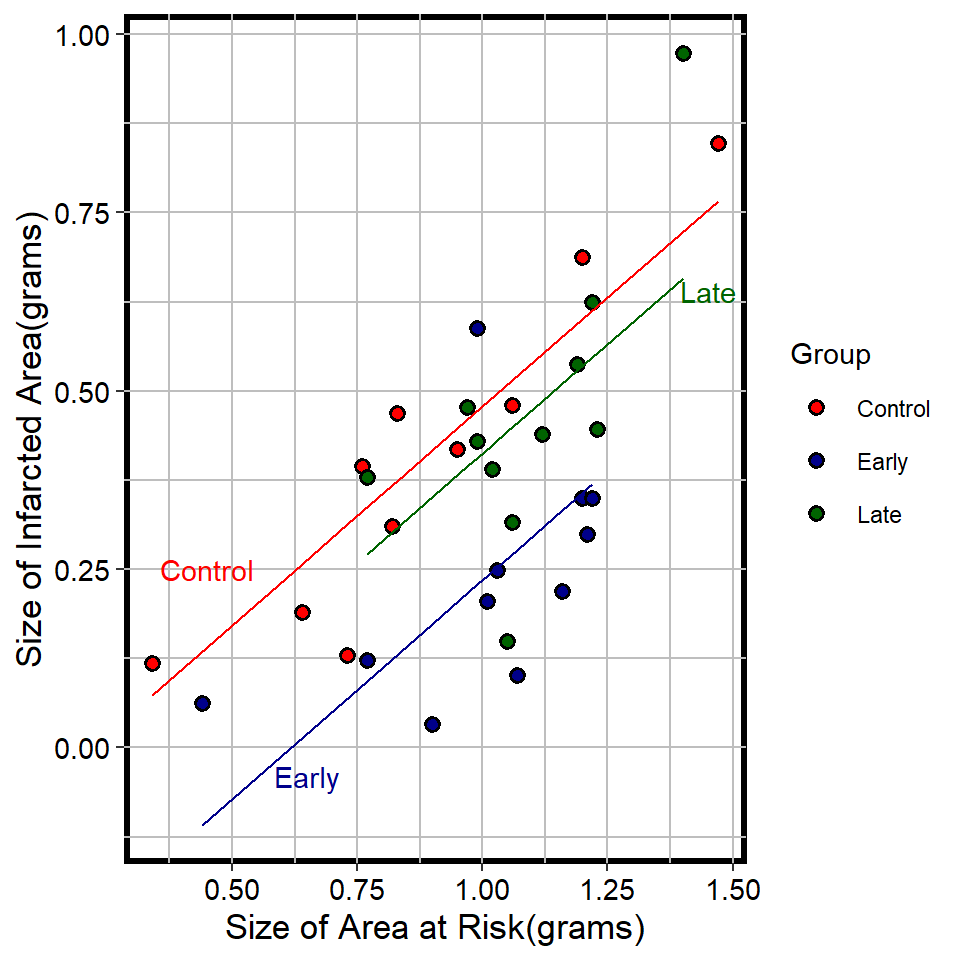

Infarcted vs Area, Grouping by cooling early/late/control of rabbits

```r
RplotterPkg::create_scatter_plot(
  df = coolhearts_dt,
  aes_x = "Area",
  aes_y = "Infect",
  aes_fill = "Group",
  rot_y_tic_label = T,
  pts_size = 2,
  x_title = "Size of Area at Risk(grams)",
  y_title = "Size of Infarcted Area(grams)",
  x_major_breaks = seq(0.25, 1.5, 0.25),
) + geom_line(aes(x = Area, y = Fit, color = Group)) +
  guides(color = "none") +
  annotate("text",x=.45,y=.25,label="Control",color="red") +
  annotate("text",x=1.45,y=.64,label="Late",color="darkgreen") +
  annotate("text",x=.65,y=-.04,label="Early",color="darkblue") +
  scale_fill_manual(values = c("red","darkblue","darkgreen")) +
  scale_color_manual(values = c("red","darkblue","darkgreen"))
```

## 6.2 General linear F-test

The Full Model

> The “full model”, which is also sometimes referred to as the “unrestricted model”, is the model thought to be the most appropriate for the data.

The Reduced Model

> The “reduced model” which is sometimes referred to as the “restricted model” is the model described by the null hypothesis $H_{0}$.

F-Statistic Test

The “general linear F-test” involves three basic steps:

1. Define a larger **full model** or **unrestricted model** (one with more parameters)
2. Define a smaller **reduced model** or **restricted model** (one with fewer parameters)
3. Use the **F-statistic** to decide whether or not to reject the smaller reduced model in favor of the larger full model

The $F$-statistic is defined as follows:

$$F = \left ( \frac{SSE_{r} - SSE_{ur}}{df_{r} - df_{ur}} \right ) \div \left ( \frac{SSE_{ur}}{df_{ur}} \right )$$
Note q = $df_{r} - df_{ur}$ = the difference in the number of predictors between the full and reduced models

An alternative definition from $F$ involves the $R^2$ values from the full and reduced models – known as the **R-squared form of the F statistic**:
$$F = \frac{(R_{ur}^2 - R_{r}^2)/q}{(1 - R_{ur}^2)/df_{ur}}$$

We use the general linear $F$-statistic to decide whether or not:

1. to reject the null hypothesis $H_{0}$: the reduced model
2. in favor of the alternative hypothesis $H_{A}$: the full model

Example: Alcohol and muscle strength data

The Hypotheses’—

```
Reduced model: $H_{0}: y_{strength} = \beta_{intercept} + \epsilon$

Full model: $H_{A}: y_{strength} = \beta_{intercept} + \beta_{alcohol} + \epsilon$
```

Set the data.

```r
data_path <- file.path(here::here(), "PennState-Stat 501 Regression Methods","data/alcoholarm.txt")
alchoholarm_dt <- data.table::fread(data_path)
```

Estimate the reduced and full models.

```r
# reduced_ols <- mean(alchoholarm_dt$strength)
# reduced_sse <- sum((alchoholarm_dt$strength - reduced_ols)^2)
# using only the intercept in the model
reduced_ols <- RregressPkg::ols_calc(
  df = alchoholarm_dt,
  formula_obj = strength ~ 1
)
reduced_sse <- reduced_ols$sse

full_ols <- RregressPkg::ols_calc(
  df = alchoholarm_dt,
  formula_obj = strength ~ alcohol
)
full_sse <- full_ols$sse
```

Display the reduced and full models.

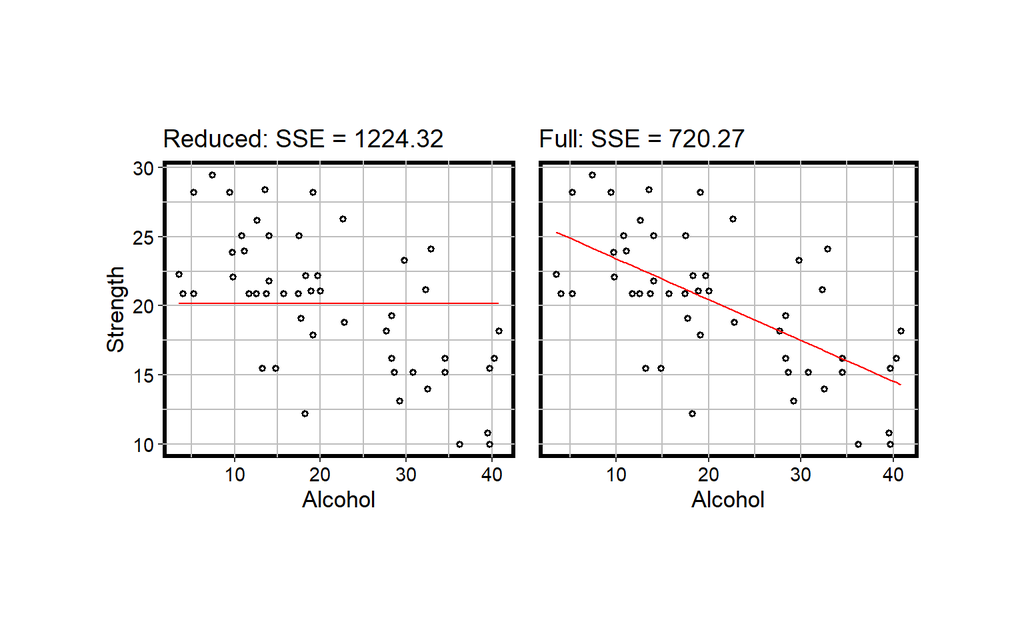

Reduced and Full Model of Alcohol vs Strength

```r
plot_df <- data.frame(
  Alcohol = alchoholarm_dt$alcohol,
  Strength = alchoholarm_dt$strength,
  Strength_R = reduced_ols$fitted_val,
  Strength_F = full_ols$fitted_val
)

reduced_plot <- RplotterPkg::create_scatter_plot(
  df = plot_df,
  aes_x = "Alcohol",
  aes_y = "Strength",
  subtitle = paste0("Reduced: SSE = ",round(reduced_sse,digits = 2)),
  x_title = "Alcohol",
  y_title = "Strength",
  rot_y_tic_label = T
) + geom_line(aes(y = Strength_R), color="red")

full_plot <- RplotterPkg::create_scatter_plot(
  df = plot_df,
  aes_x = "Alcohol",
  aes_y = "Strength",
  subtitle = paste0("Full: SSE = ",round(full_sse, digits = 2)),
  x_title = "Alcohol",
  rot_y_tic_label = T,
  y_title = NULL,
  hide_y_tics = T
) + geom_line(aes(y = Strength_F), color="red")

layout <- list(
  plots = list(reduced_plot, full_plot),
  rows = c(1,1),
  cols = c(1,2)
)
RplotterPkg::multi_panel_grid(
  layout = layout,
  col_widths = c(8.5,8),
  row_heights = 8
)
```

Show the ANOVA from the full and reduced models.

```r
RplotterPkg::create_table(
  x = full_ols$anova_df,
  container_width_px = 400
)
```

Full Model ANOVA

| Source | DF | SS | MS |
| --- | --- | --- | --- |
| Regression | 1 | 504.0403 | 504.04032 |
| Error | 48 | 720.2749 | 15.00573 |
| Total | 49 | 1224.3152 | 24.98602 |

```r
RplotterPkg::create_table(
  x = reduced_ols$anova_df,
  container_width_px = 400
)
```

Reduced Model ANOVA

| Source | DF | SS | MS |
| --- | --- | --- | --- |
| Regression | 0 | 5.768151e-27 | Inf |
| Error | 49 | 1.224315e+03 | 24.98602 |
| Total | 49 | 1.224315e+03 | 24.98602 |

The resulting F value.

$F = \frac{MSR_{fullmodel}}{MSE_{fullmodel}} = \frac{504.04/1}{720.27/48} = \frac{504.044}{15.006}=33.59$

## 6.3 Sequential (or extra) sums of squares

> The numerator of the general linear F-statistic ($SSE_{restricted} - SSE_{unstricted}$ is what is referred to as a “sequential sum of the squares.” It can be viewed in either of two ways:
1. It is the reduction in the **error sum of the squares** (SSE) when one or more predictor variables are added to the model
2. It is the increase in the **regression sum of the squares** (SSR) when one or more predictors are added to the model

Try it!

> These problems review the concept of “sequential(or extra) sums of squares.”

Using the brain size and body size study data. Set up the data.

```r
data_path <- file.path(here::here(), "PennState-Stat 501 Regression Methods","data/iqsize.txt")
iqsize_dt <- data.table::fread(data_path)
```

1. $X_{Brain}$ as the only predictor:

```r
brain_ols <- RregressPkg::ols_calc(
  df = iqsize_dt,
  formula_obj = PIQ ~ Brain
)
```

```r
RplotterPkg::create_table(
  x = brain_ols$anova_df,
  container_width_px = 400
)
```

PIQ ~ Brain

| Source | DF | SS | MS |
| --- | --- | --- | --- |
| Regression | 1 | 2697.094 | 2697.0939 |
| Error | 36 | 16197.459 | 449.9294 |
| Total | 37 | 18894.553 | 510.6636 |

$SSE(X_{brain})=16197$ $SSR(X_{brain})=2697$ $SSTO=18895$

2. Fit with regressors (in order) $X_{Brain}$ and $X_{Height}$

```r
brain_height_ols <- RregressPkg::ols_calc(
  df = iqsize_dt,
  formula_obj = PIQ ~ Brain + Height
)
```

```r
RplotterPkg::create_table(
  x = brain_height_ols$anova_df,
  container_width_px = 400
)
```

PIQ ~ Brain + Height

| Source | DF | SS | MS |
| --- | --- | --- | --- |
| Regression | 2 | 5572.741 | 2786.3706 |
| Error | 35 | 13321.811 | 380.6232 |
| Total | 37 | 18894.553 | 510.6636 |

$SSE(X_{brain},X_{height})=13322$ $SSR(X_{brain},X_{height})=5573$ $SSTO=18895$

3. Sequential sum of the squares: Of adding Height where Brain is the only predictor SSR(Height|Brain)

SSR(Height|Brain) = Reduction in error sum of the squares = SSE(Brain) - SSE(Brain,Height) = 16197 - 13322 = 2875

Or

SSR(Height|Brain) = Increase in regression sum of the squares = SSR(Brain,Height) - SSR(Brain) = 5573 - 2697 = 2876

4. (MiniTab question)
5. Order matters – add the predictors in the reverse order – $X_{Height}$ then $X_{Brain}$:

```r
height_ols <- RregressPkg::ols_calc(
  df = iqsize_dt,
  formula_obj = PIQ ~ Height
)
```

```r
RplotterPkg::create_table(
  x = height_ols$anova_df,
  container_width_px = 400
)
```

PIQ ~ Height

| Source | DF | SS | MS |
| --- | --- | --- | --- |
| Regression | 1 | 163.9662 | 163.9662 |
| Error | 36 | 18730.5864 | 520.2941 |
| Total | 37 | 18894.5526 | 510.6636 |

Now add in the Brain to the model:

```r
height_brain_ols <- RregressPkg::ols_calc(
  df = iqsize_dt,
  formula_obj = PIQ ~ Height + Brain
)
```

```r
RplotterPkg::create_table(
  x = height_brain_ols$anova_df,
  container_width_px = 400
)
```

PIQ ~ Height + Brain

| Source | DF | SS | MS |
| --- | --- | --- | --- |
| Regression | 2 | 5572.741 | 2786.3706 |
| Error | 35 | 13321.811 | 380.6232 |
| Total | 37 | 18894.553 | 510.6636 |

The sequential sums of the squares:

SSR(Brain|Height) = reduction in sum of squares of errors = SSE(Height) - SSE(Brain|Height) = 18731 - 13322 = 5409

Or

SSR(Brain|Height) = increase in sum of squares of regression = SSR(Brain|Height) - SSR(Height) = 5573 - 164 = 5409

6. Sequential sums of the squares for any number of predictors. Build a model in order: $X_{Brain}$, $X_{Height}$, $X_{Weight}$

Start with only $X_{Brain}$:

```r
brain_ols <- RregressPkg::ols_calc(
  df = iqsize_dt,
  formula_obj = PIQ ~ Brain
)
```

```r
RplotterPkg::create_table(
  x = brain_ols$anova_df,
  container_width_px = 400
)
```

PIQ ~ Brain

| Source | DF | SS | MS |
| --- | --- | --- | --- |
| Regression | 1 | 2697.094 | 2697.0939 |
| Error | 36 | 16197.459 | 449.9294 |
| Total | 37 | 18894.553 | 510.6636 |

Add in $X_{Height}$:

```r
brain_height_ols <- RregressPkg::ols_calc(
  df = iqsize_dt,
  formula_obj = PIQ ~ Brain + Height
)
```

```r
RplotterPkg::create_table(
  x = brain_height_ols$anova_df,
  container_width_px = 400
)
```

PIQ ~ Brain + Height

| Source | DF | SS | MS |
| --- | --- | --- | --- |
| Regression | 2 | 5572.741 | 2786.3706 |
| Error | 35 | 13321.811 | 380.6232 |
| Total | 37 | 18894.553 | 510.6636 |

Sequential increase in regression sum of squares:

SSR(Height|Brain) = 5573 - 2697 = 2876

Now add in $X_{Weight}$ to the model:

```r
brain_height_weight_ols <- RregressPkg::ols_calc(
  df = iqsize_dt,
  formula_obj = PIQ ~ Brain + Height + Weight
)
```

```r
RplotterPkg::create_table(
  x = brain_height_weight_ols$anova_df,
  container_width_px = 400
)
```

PIQ ~ Brain + Height + Weight

| Source | DF | SS | MS |
| --- | --- | --- | --- |
| Regression | 3 | 5572.744 | 1857.5815 |
| Error | 34 | 13321.808 | 391.8179 |
| Total | 37 | 18894.553 | 510.6636 |

Sequential increase in regression sum of squares:

SSR(Weight|Brain,Height) = 5572.744 - 5572.741 = 0.003

7. The above was **one-degree-of-freedom** sequential sums of squares – adding predictors one at a time – used for testing $H_{0}: \beta_{1} = 0$

**two-degree-of-freedom** sequential sums of squares – adding two predictors at a time: Start with only $X_{Brain}$:

```r
brain_ols <- RregressPkg::ols_calc(
  df = iqsize_dt,
  formula_obj = PIQ ~ Brain
)
```

```r
RplotterPkg::create_table(
  x = brain_ols$anova_df,
  container_width_px = 400
)
```

PIQ ~ Brain

| Source | DF | SS | MS |
| --- | --- | --- | --- |
| Regression | 1 | 2697.094 | 2697.0939 |
| Error | 36 | 16197.459 | 449.9294 |
| Total | 37 | 18894.553 | 510.6636 |

Now add in $X_{Height}$ and $X_{Weight}$:

```r
brain_height_weight_ols <- RregressPkg::ols_calc(
  df = iqsize_dt,
  formula_obj = PIQ ~ Brain + Height + Weight
)
```

```r
RplotterPkg::create_table(
  x = brain_height_weight_ols$anova_df,
  container_width_px = 400
)
```

PIQ ~ Brain + Height + Weight

| Source | DF | SS | MS |
| --- | --- | --- | --- |
| Regression | 3 | 5572.744 | 1857.5815 |
| Error | 34 | 13321.808 | 391.8179 |
| Total | 37 | 18894.553 | 510.6636 |

Sequential sum squares:

SSR(Height,Weight|Brain) = increase in regression sum of the squares = 5573 - 2697 = 2876

## 6.4 Hypothesis tests for the slopes

Returning to the 3 hypothesis in section 6.1 above(a.,b.,c.), we will test each hypothesis using *coolhearts.txt* data and the general linear $F$-statistic:
$$F = \left ( \frac{SSE_{r} - SSE_{ur}}{df_{r} - df_{ur}} \right ) \div \left ( \frac{SSE_{ur}}{df_{ur}} \right )$$

Using the coolhearts data set, read the data.

```r
data_path <- file.path(here::here(), "PennState-Stat 501 Regression Methods","data/coolhearts.txt")
coolhearts_dt <- data.table::fread(data_path)
coolhearts_dt <- coolhearts_dt[, .(Infect = `Inf`, Area = Area, Early = X2, Late = X3, Group = Group)]
```

$H_{0}$: Testing all slope parameters equal 0

From 6.1, a. $H_{1}$: Is at least one slope parameter non-zero?

$H_{0}: \beta_{Area} = \beta_{Early} = \beta_{Late} = 0$

$H_{A}:$ At least one $\beta_{j} \ne 0$ (for $j$ = Area,Early,Late)

Compute the $F$ value.

```r
F_lst <- RregressPkg::ols_restricted_model(
  df = coolhearts_dt,
  ur_formula_obj = Infect ~ Area + Early + Late,
  r_formula_obj = Infect ~ 1,
  confid_level = 0.99
)
```

```r
RplotterPkg::create_table(
  x = F_lst$F_df,
  container_width_px = 400
)
```

Is at least one slope parameter non-zero?

| F.Value | Critical | numer_df | denom_df | confid_lv | p.value |
| --- | --- | --- | --- | --- | --- |
| 16.43063 | 4.568091 | 3 | 28 | 1% | 2.36347e-06 |

The $F$ value is 16.4306307 with a critical value at 99% probability of 4.5680909. Thus there is a least one significant predictor.

$H_{0}$: Testing if one slope parameter is 0

From 6.1, b. $H_{1}$: Is a specific predictor not equal to zero?

$H_{0}: \beta_{Area} = 0$

$H_{A}: \beta_{Area} \ne 0$

Compute the $F$ value.

```r
F_lst <- RregressPkg::ols_restricted_model(
  df = coolhearts_dt,
  ur_formula_obj = Infect ~ Area + Early + Late,
  r_formula_obj = Infect ~ Early + Late,
  confid_level = 0.99
)
```

```r
RplotterPkg::create_table(
  x = F_lst$F_df,
  container_width_px = 400
)
```

Is a specific predictor not equal to zero?

| F.Value | Critical | numer_df | denom_df | confid_lv | p.value |
| --- | --- | --- | --- | --- | --- |
| 32.7536 | 7.635619 | 1 | 28 | 1% | 3.865441e-06 |

The $F$ value is 32.7536006 with a critical value at 99% probability of 7.6356194. Thus *Area* is a significant predictor.

Testing a subset of slope parameters is 0

From 6.1, c. $H_{1}$: Is a subset(more than one but not all) of the predictors simultaneously zero?

$H_{0}: \beta_{Early} = \beta_{Late} = 0$

$H_{A}:$ At least one $\beta_{j} \ne 0$ (for $j$ = Early, Late)

Compute the $F$ value.

```r
F_lst <- RregressPkg::ols_restricted_model(
  df = coolhearts_dt,
  ur_formula_obj = Infect ~ Area + Early + Late,
  r_formula_obj = Infect ~ Area,
  confid_level = 0.99
)
```

```r
RplotterPkg::create_table(
  x = F_lst$F_df,
  container_width_px = 400
)
```

Is a subset(more than one but not all) of the predictors simultaneously zero?

| F.Value | Critical | numer_df | denom_df | confid_lv | p.value |
| --- | --- | --- | --- | --- | --- |
| 8.590176 | 5.452937 | 2 | 28 | 1% | 0.001232872 |

The $F$ value is 8.5901761 with a critical value at 99% probability of 5.4529369. Thus there is a least one significant predictor in the subset. Or we can say that cooling has a significant influence on the extent of damage that occurs after taking into account the size of the region (*Area*).